# Assignment 8: Fitting Variables

Luke Ghallahorne

2025-05-22

```r
library(mvabund) # spider data
library(vegan) # metaMDS(), envfit()
library(tidyverse) # ggplot()
library(GGally) # ggpairs()
library(corrplot) # corrplot()
library(PNWColors) # pnw_palette()
library(dendextend) # color_branches(), color_labels()
```

```r
# Color Palettes
pal1 <- pnw_palette("Bay", 6)
pal2 <- pnw_palette("Bay", 4)
```

```r
data(spider)
# ?spider
```

# Introduction

These data consist of community abundance for twelve hunting spider species, as well as six environmental variables describing the species’ habitats.

Spider Species:

- *Alopecosa accentuata*
- *Alopecosa cuneata*
- *Alopecosa fabrilis*
- *Arctosa lutetiana*
- *Arctosa perita*
- *Aulonia albimana*
- *Pardosa lugubris*
- *Pardosa monticola*
- *Pardosa nigriceps*
- *Pardosa pullata*
- *Trochosa terricola*
- *Zora spinimana*

Species are abbreviated with the first four letters of the genus name followed by the first four letters of the species name.

Environmental Variables:

- soil.dry: soil dry mass
- bare.sand: cover bare sand
- fallen.leaves: cover fallen leaves/twigs
- moss: cover moss
- herb.layer: cover herb layer
- reflection: reflection of the soil surface with a cloudless sky

The environmental variables were log(x+1)-transformed.

## Pairs Plot [,1:6]

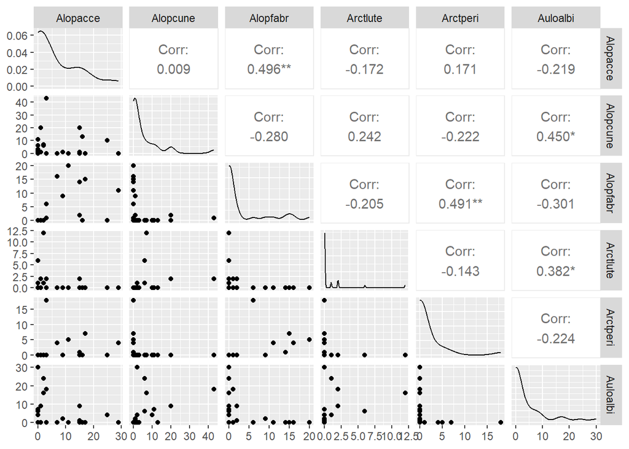

```r
spider.abund <- data.frame(spider$abund)
spider.env <- data.frame(spider$x)
ggpairs(spider.abund[,1:6])
```

## Pairs Plot [,7:12]

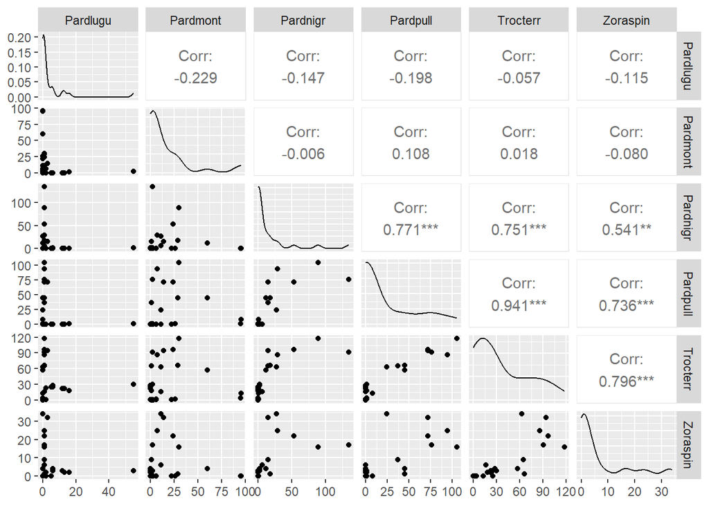

```r
ggpairs(spider.abund[,7:12])
```

## Correlation Plot

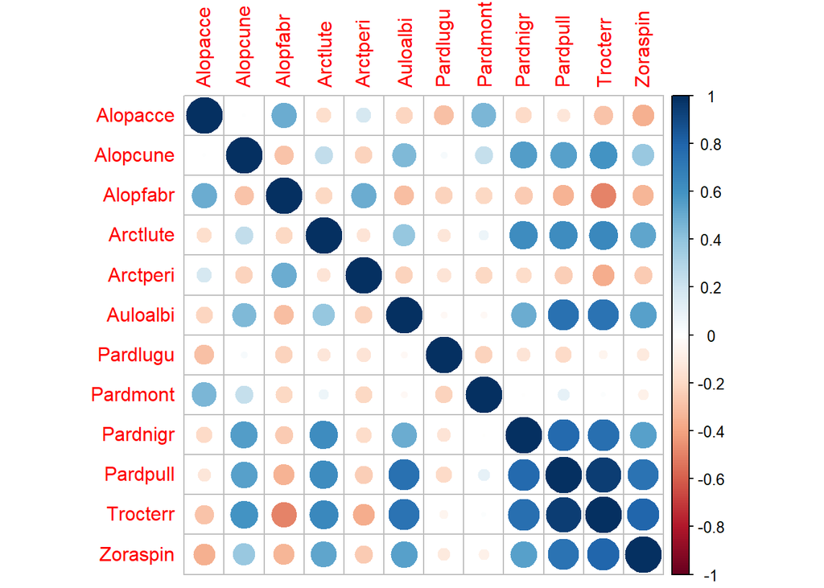

```r
M <- cor(spider.abund)
corrplot(M)
```

The goal of this analysis is to answer the questions:

- **Is there an observable pattern in these 28 observations of hunting spider communities?**
- **If so, do the environmental variables explain any of those patterns?**

# Methods

## Ordination

To better visualize these data, I used nonmetric Multidimensional Scaling (nMDS), an iterative ordination method ideal for community abundance data. For distance/dissimilarity measures in nMDS, I used Bray-Curtis measurements because they better account for non-normal data with many zeros than Euclidean measurements. I chose two axes for the ordination plot, as the stress was very low (0.065) and the non-metric R^2 quite high (0.996), showing that the two axes describe the majority of variation.

I used averages of each species weighted by nMDS axes 1 and 2 to plot the species scores alongside the sample points to show which species are common among certain plots.

```r
set.seed(42)

spider.nmds <- metaMDS(spider.abund, k = 2)
```

```
## Square root transformation
## Wisconsin double standardization
## *** Best solution repeated 6 times
```

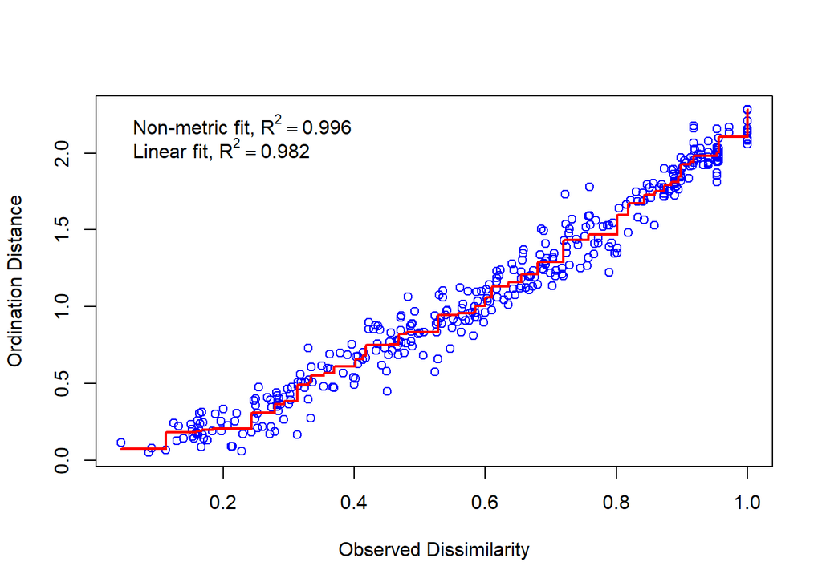

```r
stressplot(spider.nmds)
```

## Cluster Analysis

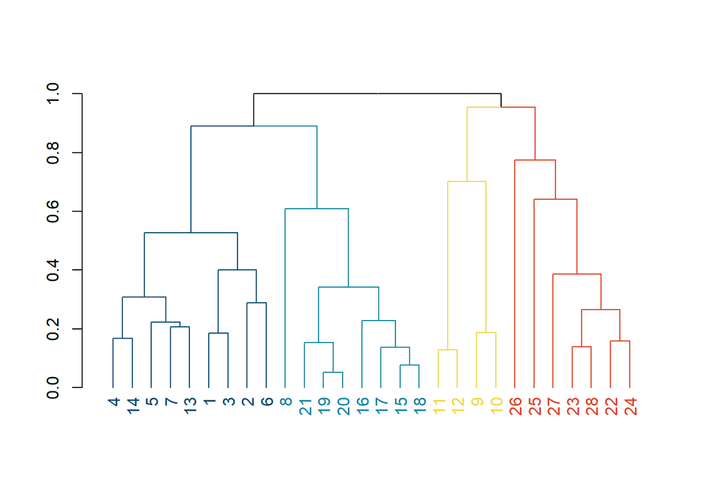

```r
spider.dist <- vegdist(spider.abund, method = "bray")
spider.hcl <- hclust(spider.dist)
spider.dend <- as.dendrogram(spider.hcl)
spider.clust <- cutree(spider.hcl, k = 4)

spider.dend <- spider.dend |>
  color_branches(k = 4, col = pal2) |>
  color_labels(k = 4, col = pal2)

plot(spider.dend)
```

## Fitting Environmental Variables

To fit environmental variables back onto the ordination space, I regressed each continuous variable onto nMDS1 and nMDS2. This produced a vector in the nMDS space that shows the maximum gradient of change for each variable, as well as R^2 goodness of fit values, and permuted p-values for the significance of that R^2. The length of the vector represents the scaled magnitude of that gradient.

```r
set.seed(42)

my.fit <- envfit(spider.nmds, spider.env, choices = c(1,2))
my.fit
```

```
##
## ***VECTORS
##
##                  NMDS1    NMDS2     r2 Pr(>r)
## soil.dry       0.92607 -0.37735 0.8754  0.001 ***
## bare.sand     -0.88772  0.46039 0.6225  0.001 ***
## fallen.leaves  0.62677  0.77920 0.8001  0.001 ***
## moss          -0.90185 -0.43205 0.7144  0.001 ***
## herb.layer     0.03014 -0.99955 0.4530  0.002 **
## reflection    -0.86687 -0.49853 0.7996  0.001 ***
## ---
## Signif. codes:  0 '***' 0.001 '**' 0.01 '*' 0.05 '.' 0.1 ' ' 1
## Permutation: free
## Number of permutations: 999
```

## PERMANOVA

$Y \sim soil.dry + fallen.leaves + reflection + moss + bare.sand + herb.layer$

# Results

## Ordination

```r
# nMDS Scores and Clusters for Abundance Dataframe for Plotting
spiderPlot <- data.frame(
  NMDS1 <- spider.nmds$points[,1],
  NMDS2 <- spider.nmds$points[,2],
  Cluster <- as.factor(spider.clust))

# Environmental Variables Dataframe for Plotting
vecPlot <- as.data.frame(scores(my.fit,
                                display = "vectors"))

vecPlot <- cbind(vecPlot,
                 Vname = rownames(vecPlot),
                 Pvalues = my.fit$vectors$pvals,
                 R_squared = my.fit$vectors$r)
# Filter by significant p value (not necessary here but kept for reference)
vecPlot <- subset(vecPlot, Pvalues < 0.05)

# Species Scores Dataframe for Plotting
Species1 <- spider.nmds$species[,1]
Species2 <- spider.nmds$species[,2]
Names <- rownames(spider.nmds$species)
speciesPlot <- data.frame(Species1, Species2, Names)
```

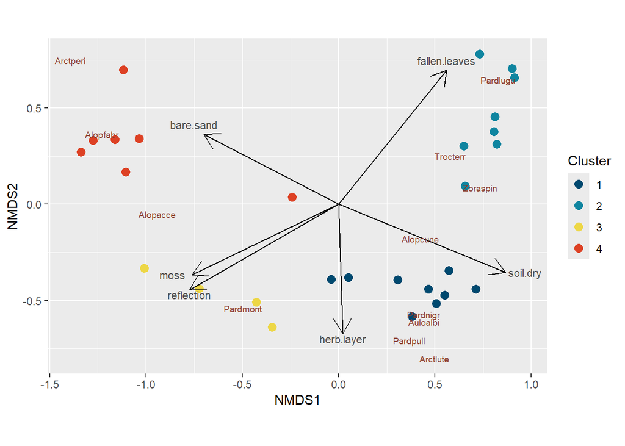

```r
# Ordination Plot
plot1 <- ggplot() +
  geom_point(data = spiderPlot,
             aes(x = NMDS1, y = NMDS2, color = Cluster),
                 size = 3) +
  coord_fixed() +
  xlab("NMDS1") +
  ylab("NMDS2") +
  scale_color_manual(values = pal2) +
  geom_segment(data = vecPlot,
               aes(x = 0, xend = NMDS1,
                   y = 0, yend = NMDS2),
               arrow =
                 arrow(length = unit(0.5, "cm"))) +
  geom_text(data = speciesPlot,
            aes(x = Species1, y = Species2,
                label = Names),
            size = 2.5, color = "coral4") +
  geom_text(data = vecPlot,
            aes(x = NMDS1, y = NMDS2,
                label = Vname),
            color = "grey30",
            size = 3,
            nudge_x = c(0.1, -0.05, 0, -0.1, 0, 0),
            nudge_y = c(0, 0.05, 0.05, 0, -0.025, -0.025))
plot1
```

Figure 1. Non-Metric Multidimensional Scaling of hunting spider communities (stress = 0.0646, non-metric $R^2$ = 0.996). Colors depict clusters determined from hierarchical cluster analysis. Arrow vectors show fitted environmental variables in the direction of strongest gradient of change. Vector lengths represent scales magnitude of the gradient. Maroon text shows the species scores for each spider.

```r
abundPlot <- data.frame(Cluster <- as.factor(spider.clust),
                        ID <- as.factor(1:nrow(spider.abund)))

abundPlot <- cbind(abundPlot,
                   spider.abund)
abundPlot
```

```
##    Cluster....as.factor.spider.clust. ID....as.factor.1.nrow.spider.abund..
## 1                                   1                                     1
## 2                                   1                                     2
## 3                                   1                                     3
## 4                                   1                                     4
## 5                                   1                                     5
## 6                                   1                                     6
## 7                                   1                                     7
## 8                                   2                                     8
## 9                                   3                                     9
## 10                                  3                                    10
## 11                                  3                                    11
## 12                                  3                                    12
## 13                                  1                                    13
## 14                                  1                                    14
```

[output cut: 72 more lines]

```r
abund.long <- abundPlot |>
  gather(key = "Species", value = "Count", 3:14)
colnames(abund.long) <- c("Cluster", "ID", "Species", "Count")
abund.long
```

```
##     Cluster ID  Species Count
## 1         1  1 Alopacce    25
## 2         1  2 Alopacce     0
## 3         1  3 Alopacce    15
## 4         1  4 Alopacce     2
## 5         1  5 Alopacce     1
## 6         1  6 Alopacce     0
## 7         1  7 Alopacce     2
## 8         2  8 Alopacce     0
## 9         3  9 Alopacce     1
## 10        3 10 Alopacce     3
## 11        3 11 Alopacce    15
## 12        3 12 Alopacce    16
## 13        1 13 Alopacce     3
## 14        1 14 Alopacce     0
```

[output cut: 322 more lines]

```r
abund.sub <- filter(abund.long, Count > 0)
abund.sub
```

```
##     Cluster ID  Species Count
## 1         1  1 Alopacce    25
## 2         1  3 Alopacce    15
## 3         1  4 Alopacce     2
## 4         1  5 Alopacce     1
## 5         1  7 Alopacce     2
## 6         3  9 Alopacce     1
## 7         3 10 Alopacce     3
## 8         3 11 Alopacce    15
## 9         3 12 Alopacce    16
## 10        1 13 Alopacce     3
## 11        4 22 Alopacce     7
## 12        4 23 Alopacce    17
## 13        4 24 Alopacce    11
## 14        4 25 Alopacce     9
```

[output cut: 168 more lines]

## PERMANOVA

```r
set.seed(42)
Y <- as.matrix(spider.abund)
spider.PERM <- adonis2(Y ~ spider.env$soil.dry + spider.env$fallen.leaves + spider.env$reflection + spider.env$moss + spider.env$bare.sand + spider.env$herb.layer, method = "bray")
spider.PERM
```

```
## Permutation test for adonis under reduced model
## Permutation: free
## Number of permutations: 999
##
## adonis2(formula = Y ~ spider.env$soil.dry + spider.env$fallen.leaves + spider.env$reflection + spider.env$moss + spider.env$bare.sand + spider.env$herb.layer, method = "bray")
##          Df SumOfSqs      R2      F Pr(>F)
## Model     6   5.8906 0.72157 9.0705  0.001 ***
## Residual 21   2.2730 0.27843
## Total    27   8.1636 1.00000
## ---
## Signif. codes:  0 '***' 0.001 '**' 0.01 '*' 0.05 '.' 0.1 ' ' 1
```

# Discussion

Environmental variables mapped into different areas of the nMDS space. Fallen leaves were positive in nMDS1 and nMDS2, opposite from high values of moss and reflection. Furthermore, moss and reflection mapped onto similar gradients, so they likely explain similar variation among sites. Bare sand and dry soil are also mapped opposite one another, implying that they explain similar variation in opposite directions. Herb layer is not strongly represented in nMDS1, but has a noticeable influence on nMDS2, with high herb layer values reflected in negative nMDS2 scores.

Clusters show apparent trends to have similar environmental characteristics. Cluster 1 sites typically have dry soil and some herb layer. Cluster 2 sites are dominated by fallen leaves. Cluster 3 tends toward high values of moss and reflection, and cluster 4 consists of mainly bare sand habitats.

# Conclusions

# Reflection

I actually really enjoyed this assignment - it felt like a solid synthesis and conclusion of the ordinations we have been working with.

I wanted to go a little further with this one for the draft, but with a proposal deadline the same evening, this is as far as I got. If I have the time before Wednesday, I would like to include the PERMANOVA to see how the environmental variables are actually explaining the data. I also would like to include abundance bar plots for each cluster to better show how each differs.